# Using the qs package

# qs – quick serialization of R objects

This package provides an interface for quickly writing (serializing) and reading (de-serializing) objects to and from disk. The goal of this package is to provide a lightning-fast and complete replacement for the saveRDS and readRDS functions in R.

Inspired by the fst package, qs uses a similar block-compression approach using the zstd library and direct “in memory” compression, which allows for lightning quick serialization. It differs in that it uses a more general approach for attributes and object references for common data types (numeric data, strings, lists, etc.), meaning any S3 object built on common data types, e.g., tibbles, time-stamps, bit64, etc. can be serialized. For less common data types (formulas, environments, functions, etc.), qs relies on built in R serialization functions via the RApiSerialize package followed by block-compression.

For character vectors, `qs` also uses the alt-rep system to quickly read in string data.

## Features

The table below compares the features of different serialization approaches in R.

|  | qs | fst | saveRDS |
| --- | --- | --- | --- |
| Not Slow | ✔ | ✔ | ❌ |
| Numeric Vectors | ✔ | ✔ | ✔ |
| Integer Vectors | ✔ | ✔ | ✔ |
| Logical Vectors | ✔ | ✔ | ✔ |
| Character Vectors | ✔ | ✔ | ✔ |
| Character Encoding | ✔ | (vector-wide only) | ✔ |
| Complex Vectors | ✔ | ❌ | ✔ |
| Data.Frames | ✔ | ✔ | ✔ |
| On disk row access | ❌ | ✔ | ❌ |
| Attributes | ✔ | Some | ✔ |
| Lists / Nested Lists | ✔ | ❌ | ✔ |
| Multi-threaded | ❌ (Not Yet) | ✔ | ❌ |

## Summary Benchmarks

The table below lists serialization speed for several different data types (listed in MB/s).

[output not shown]

## Installation:

1. `devtools::install_git("traversc/qs")`

## Example:

See `tests/correctness_testing.r` for more examples. Below is an example serializing a large `data.frame` to disk.

```r
library(qs)
x1 <- data.frame(int = sample(1e3, replace=T), num = rnorm(1e3), char = qs::randomStrings(1e3), stringsAsFactors = F)
qsave(x1, "mydata.qs")

x2 <- qread("mydata.qs")
identical(x1, x2) # returns true
```

```
## [1] TRUE
```

## Additional Benchmarks

### Data.Frame benchmark

Benchmarks for serializing and de-serializing large data.frames (5 million rows) composed of a numeric column (`rnorm`), an integer column (`sample(5e6)`), and a character vector column (random alphanumeric strings of length 50). See `vignettes/dataframe_bench.png` for a comparison using different compression parameters.

This benchmark also includes materialization of alt-rep data, for an apples-to-apples comparison.

#### Serialization speed with default parameters:

| Method | write time (s) | read time (s) |
| --- | --- | --- |
| qs | 0.49391294 | 8.8818166 |
| fst (1 thread) | 0.37411811 | 8.9309314 |
| fst (4 thread) | 0.3676273 | 8.8565951 |
| saveRDS | 14.377122 | 12.467517 |

#### Serialization speed with different parameters

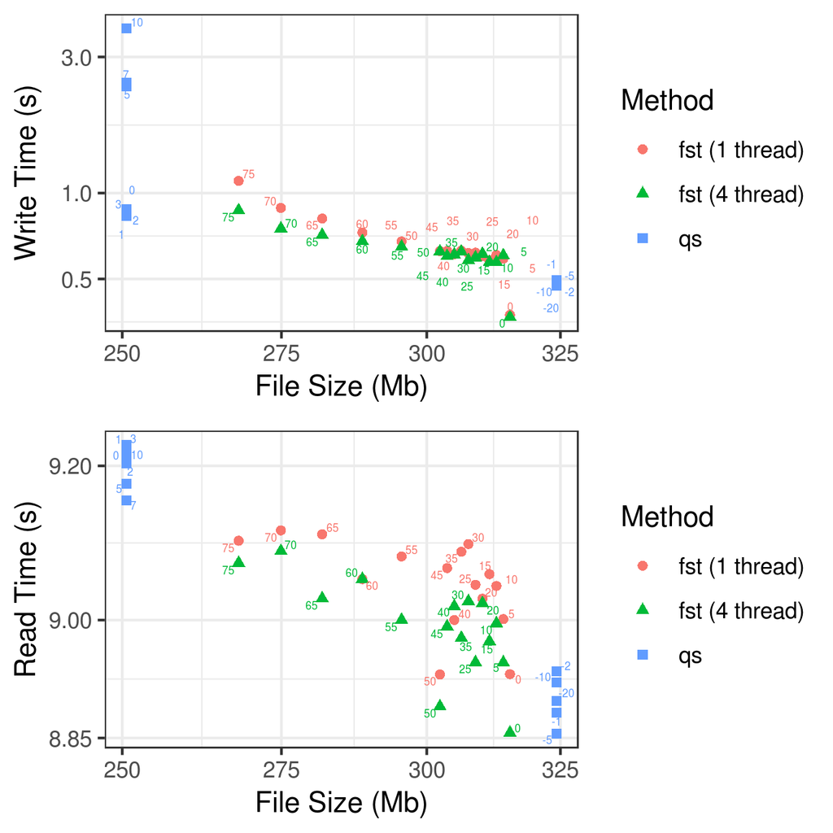

dataframe_bench

### Nested List benchmark

Benchmarks for serialization of random nested lists with random attributes (approximately 50 Mb). See the nested list example in the tests/correctness_testing.r.

#### Serialization speed with default parameters

| Method | write time (s) | read time (s) |
| --- | --- | --- |
| qs | 0.17840716 | 0.19489372 |
| saveRDS | 3.484225 | 0.58762548 |

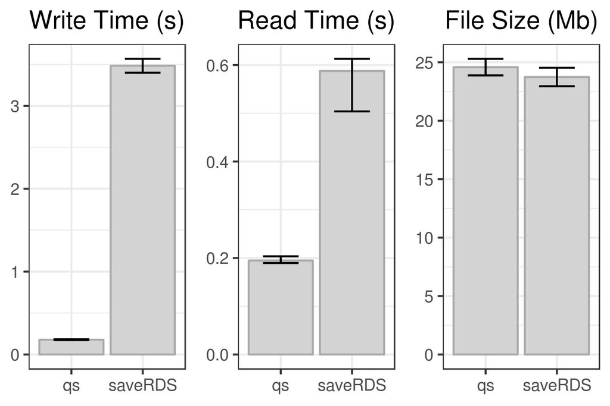

nested_list_bench